# metro_analysis

Module Code: CSMDS  
Assignment report Title: Exploratory Data Analysis of Metro Bike Dataset  
Student Number: 32824514  
Actual hrs spent for the assignment: 20h  
Which Artificial Intelligence tools used (if applicable): None

- Exploratory Data Analysis of Metro Bike Dataset
  - Overview of the Data
  - Summarising Data
- Data Cleaning and Data Transformation
  - Identifying and Dropping Irrelevant Data
  - Identifying and Handling Missing Values
  - Identifying and Handling Outliers
  - Transformation of Categorical Data - Encoding
  - Transformation of Numerical Data
- Insights and Interpretations from Data Visualizations
  - Trends of Trips
  - Trends of Trips in a Day
  - The Distributions of Numerical Columns
  - The Difference of the Trip Numbers Between Entering and Leaving Trips a Station
  - Map View of the Top Popular Trips and Stations
- Summary
- References

# Exploratory Data Analysis of Metro Bike Dataset

This is a dataset of shared bike trips from the Los Angeles Metro Bike Share, which is distributed under a ODbL license. The main purposes of this work are to pre-processing the data, to find some potential patterns of user habits and predict the trends of the trips.

## Overview of the Data

The data contains 15 columns and each row of data recorded the main information of a trip.

| Column | Description | Datatype |
| --- | --- | --- |
| trip_id | Locally unique integer that identifies the trip | Interval |
| duration | Length of trip in minutes | Ratio |
| start_time | The begin date/time of the trip | Ratio |
| end_time | The end date/time of the trip | Ratio |
| start_station | The station ID where the trip originated | Interval |
| start_lat | The latitude of the start station | Interval |
| start_lon | The longitude of the start station | Interval |
| end_station | The station ID where the trip terminated | Interval |
| end_lat | The latitude of the end station | Interval |
| end_lon | The longitude of the end station | Interval |
| bike_id | Locally unique integer that identifies the bike | Interval |
| plan_duration | The number of days of the passholder's ride plan | Ratio |
| trip_route_category | Round Trip or One Way | Nominal |
| passholder_type | The name of the passholder's plan | Ordinal |
| bike_type | the kind of bike: standard padal/electric/smart | Nominal |

```python
# import the required libraries for EDA
import pandas as pd
import numpy as np
import seaborn as sns
import matplotlib
import matplotlib.pyplot as plt
import sklearn
from sklearn.preprocessing import StandardScaler  # for standardization


# check the versions of pandas and numpy
pd.__version__, np.__version__, sns.__version__, matplotlib.__version__, sklearn.__version__
```

```
('2.2.2', '1.26.4', '0.13.2', '3.8.4', '1.4.2')
```

```python
# read the metro dataset
trips = pd.read_csv('data/metro.csv', low_memory=False)
# shows the first 5 rows of metro data
trips.head(2)
```

|  | trip_id | duration | start_time | end_time | start_station | start_lat | start_lon | end_station | end_lat | end_lon | bike_id | plan_duration | trip_route_category | passholder_type | bike_type |
| --- | --- | --- | --- | --- | --- | --- | --- | --- | --- | --- | --- | --- | --- | --- | --- |
| 0 | 124657107 | 5 | 7/1/2019 0:04 | 7/1/2019 0:09 | 4312 | 34.066990 | -118.290878 | 4410 | 34.063351 | -118.296799 | 6168 | 30 | One Way | Monthly Pass | standard |
| 1 | 124657587 | 9 | 7/1/2019 0:07 | 7/1/2019 0:16 | 3066 | 34.063389 | -118.236160 | 3066 | 34.063389 | -118.236160 | 17584 | 30 | Round Trip | Monthly Pass | electric |

The datatype of columns are expected, except start_time and end_time.

```python
# convert datetime string columns to datetime type
trips.start_time = pd.to_datetime(trips.start_time, format='%m/%d/%Y %H:%M')
trips.end_time = pd.to_datetime(trips.end_time, format='%m/%d/%Y %H:%M')

# A brief summary of the data
trips.info()
```

```
<class 'pandas.core.frame.DataFrame'>
RangeIndex: 92124 entries, 0 to 92123
Data columns (total 15 columns):
 #   Column               Non-Null Count  Dtype
---  ------               --------------  -----
 0   trip_id              92124 non-null  int64
 1   duration             92124 non-null  int64
 2   start_time           92124 non-null  datetime64[ns]
 3   end_time             92124 non-null  datetime64[ns]
 4   start_station        92124 non-null  int64
 5   start_lat            89985 non-null  float64
 6   start_lon            89985 non-null  float64
 7   end_station          92124 non-null  int64
 8   end_lat              88052 non-null  float64
 9   end_lon              88052 non-null  float64
 10  bike_id              92124 non-null  object
 11  plan_duration        92124 non-null  int64
 12  trip_route_category  92124 non-null  object
 13  passholder_type      92124 non-null  object
 14  bike_type            92124 non-null  object
dtypes: datetime64[ns](2), float64(4), int64(5), object(4)
memory usage: 10.5+ MB
```

### A Statistic about Numerical Columns

Ids such as trip id and station ids are omitted as they are not meaningful.

```python
# A statistic calculated by describe function
trips[['duration', 'start_lat', 'start_lon', 'end_lat', 'end_lon', 'plan_duration']].describe()
```

|  | duration | start_lat | start_lon | end_lat | end_lon | plan_duration |
| --- | --- | --- | --- | --- | --- | --- |
| count | 92124.000000 | 89985.000000 | 89985.000000 | 88052.000000 | 88052.000000 | 92124.000000 |
| mean | 33.168588 | 34.034786 | -118.287893 | 34.034895 | -118.286699 | 60.290977 |
| std | 129.057841 | 0.058803 | 0.073501 | 0.058790 | 0.072628 | 111.141364 |
| min | 1.000000 | 33.710979 | -118.495422 | 33.710979 | -118.495422 | 1.000000 |
| 25% | 6.000000 | 34.035801 | -118.281181 | 34.037048 | -118.280952 | 1.000000 |
| 50% | 12.000000 | 34.046810 | -118.258537 | 34.046810 | -118.258537 | 30.000000 |
| 75% | 22.000000 | 34.051941 | -118.248253 | 34.051941 | -118.248253 | 30.000000 |
| max | 1440.000000 | 34.177662 | -118.231277 | 34.177662 | -118.231277 | 999.000000 |

As the statistic table shown above, three quarters of the trips were within 22 minutes. For the duration, the number 1440 (24 hours) is not so reasonable and should be considered an outlier. Additionally, the days of plans should be scaled for facilitate analysis.

## Summarising Data

### A Brief Summary of the Data

This summary can gives us an overall felling about this dataset.

```python
# the number of total stations
num_station = len(set(trips.start_station.unique()) or set(trips.end_station.unique()))
# the begin date of all trips
begin_date = trips.start_time.iloc[0]
# the end date of all trips
end_date = trips.start_time.iloc[-1]
# the number of total trip duration in minutes
sum_duration = trips.duration.sum()
# the number of total bikes
sum_bike = trips.bike_id.unique().size
print(f'There were data of {sum_bike} bikes travaled among {num_station} stations with {sum_duration} minutes rides from {begin_date} to {end_date}.')
```

```
There were data of 2042 bikes travaled among 183 stations with 3055623 minutes rides from 2019-07-01 00:04:00 to 2019-09-30 23:58:00.
```

### The most popular stations

This is an overview of the most popular start stations and end stations.

```python
# numbers of trips of start stations
start_station_nums = trips.start_station.value_counts()
# numbers of trips of end stations
end_station_nums = trips.end_station.value_counts()
start_station_nums[:3], end_station_nums[:3]
```

```
(start_station
 3005    4512
 3030    3944
 3014    3231
 Name: count, dtype: int64,
 end_station
 3005    4649
 3014    3496
 3030    3469
 Name: count, dtype: int64)
```

The result shows that the most popular starting stations were also almost the most popular destinations. But there were also a difference in numbers between entering and leaving a station, which means additional actions are required to prevent the bike from idling. This issue will be discussed further below.

### An Overview of the Bikes and Trips

There is an overview of the numbers of bikes, the numbers of trips and the numbers of trip durations by bike types.

```python
print(f'The numbers of bikes by bike type:\n{trips.groupby("bike_type")["bike_id"].nunique()}\n')
print(f'The numbers of trips by bike type: \n{trips.groupby("bike_type")["bike_id"].count()}\n')
print(f'The numbers of durations (by hours) by bike type: \n{(trips.groupby("bike_type")["duration"].sum()/60).astype("int")}\n')
```

```
The numbers of bikes by bike type:
bike_type
electric     328
smart        637
standard    1077
Name: bike_id, dtype: int64

The numbers of trips by bike type:
bike_type
electric    46446
smart       16201
standard    29477
Name: bike_id, dtype: int64

The numbers of durations (by hours) by bike type:
bike_type
electric    23664
smart       12295
standard    14967
Name: duration, dtype: int32
```

The output above shows that though electric bikes are just about 15% of all bikes, they supported over a half of the trips and over 45% of the trip time.

### An Overview of the Number of Trips by Bike Type and Passholder Type

There a summary of the number of trips by bike type and passholder type.

```python
# calculate the numbers of trips
pd.crosstab(trips.passholder_type, trips.bike_type, margins=True)
```

| bike_type passholder_type | electric | smart | standard | All |
| --- | --- | --- | --- | --- |
| Annual Pass | 3467 | 278 | 2475 | 6220 |
| Flex Pass | 2 | 0 | 4 | 6 |
| Monthly Pass | 35556 | 4656 | 16963 | 57175 |
| One Day Pass | 1047 | 3165 | 963 | 5175 |
| Testing | 0 | 46 | 0 | 46 |
| Walk-up | 6374 | 8056 | 9072 | 23502 |
| All | 46446 | 16201 | 29477 | 92124 |

The results above show that there were over 60% trips from monthly users, 62% of which used electric bikes. In contrast, walk-up users prefered standard pedal-powered (38%) and smart (34%) bikes.

### An Overview of the Number of Trip Durations by Bike Type and Passholder Type

There a summary of the number of trip durations (in hours) by bike type and passholder type.

```python
# calculate the numbers of trip durations
pd.crosstab(trips.passholder_type, trips.bike_type, values=trips.duration/60, aggfunc="sum", margins=True).fillna(0).astype("int")
```

| bike_type passholder_type | electric | smart | standard | All |
| --- | --- | --- | --- | --- |
| Annual Pass | 1071 | 76 | 476 | 1623 |
| Flex Pass | 0 | 0 | 0 | 0 |
| Monthly Pass | 9876 | 1754 | 3478 | 15108 |
| One Day Pass | 1640 | 3174 | 2046 | 6861 |
| Testing | 0 | 22 | 0 | 22 |
| Walk-up | 11076 | 7267 | 8966 | 27310 |
| All | 23664 | 12295 | 14967 | 50927 |

The results above show that there were over a half of the trip time from walk-up users, two fifths of which used electric bikes. Monthly users contributed nearly 30% of the trip durations, over three fifths of which used electric bikes.

# Data Cleaning and Data Transformation

## Identifying and Dropping Irrelevant Data

Column trip_id is the id of a trip and not meaningful for further analysis. Additionally, end_time is meaningful, but it can be calculated by start_time + duration, which means it is redundant. Besides, column trip_route_category is the type of trip such as round trip or one way, which means start_station == end_station and it is also redundant.

```python
# check and make sure the column would be dropped twice and avoid errors
trips = trips.drop(columns=['trip_id', 'end_time', 'trip_route_category'], axis=1)
trips.head()
```

|  | duration | start_time | start_station | start_lat | start_lon | end_station | end_lat | end_lon | bike_id | plan_duration | passholder_type | bike_type |
| --- | --- | --- | --- | --- | --- | --- | --- | --- | --- | --- | --- | --- |
| 0 | 5 | 2019-07-01 00:04:00 | 4312 | 34.066990 | -118.290878 | 4410 | 34.063351 | -118.296799 | 6168 | 30 | Monthly Pass | standard |
| 1 | 9 | 2019-07-01 00:07:00 | 3066 | 34.063389 | -118.236160 | 3066 | 34.063389 | -118.236160 | 17584 | 30 | Monthly Pass | electric |
| 2 | 5 | 2019-07-01 00:20:00 | 4410 | 34.063351 | -118.296799 | 4312 | 34.066990 | -118.290878 | 18920 | 30 | Monthly Pass | electric |
| 3 | 20 | 2019-07-01 00:44:00 | 3045 | 34.028511 | -118.256668 | 4275 | 34.012520 | -118.285896 | 6016 | 1 | Walk-up | standard |
| 4 | 27 | 2019-07-01 00:44:00 | 3035 | 34.048401 | -118.260948 | 3049 | 34.056969 | -118.253593 | 5867 | 30 | Monthly Pass | standard |

## Identifying and Handling Missing Values

### Count Missing Values by Columns

```python
trips.isnull().sum()
```

```
duration              0
start_time            0
start_station         0
start_lat          2139
start_lon          2139
end_station           0
end_lat            4072
end_lon            4072
bike_id               0
plan_duration         0
passholder_type       0
bike_type             0
dtype: int64
```

As results shown above, there were missing values in columns of latitude and longitude of start and end station.

### Stations without Location Infomation

```python
# check the station list without latitude and longitude
ms_stations = list(set(trips[pd.isnull(trips.start_lat)].start_station.unique())
                   & set(trips[pd.isnull(trips.end_lat)].end_station.unique()))
ms_stations
```

```
[3000, 4285, 4286]
```

```python
# check if any trip recorded the location information of the stations above
print('The number of trips recorded the location information of the missed-value stations')
for _station in ms_stations:
    print(_station, len(trips[((trips.start_station==_station)&(-pd.isna(trips.start_lat)))|((trips.end_station==_station&(-pd.isna(trips.end_lat))))]))
```

```
The number of trips recorded the location information of the missed-value stations
3000 0
4285 0
4286 0
```

As the above result shown, these stations had not location information recorded. As the statistics shown, most of the trips were less than 22 minutes, so it makes sense to predict location from trips.

### The Smallest Number by Minutes of Trips from Missed-Location Stations

```python
# Get a list of trips with duration and start_station columns which is not round trips and less than 3 minutes
durations = trips[['duration', 'start_station']]\
                [(trips.duration < 3) & (trips.start_station != trips.end_station)].drop_duplicates()
# Extract trips for stations listed and sorted
durations[(durations.start_station == 3000) | (durations.start_station == 4285) | (durations.start_station == 4286)].sort_values('duration')
```

|  | duration | start_station |
| --- | --- | --- |
| 3406 | 1 | 4286 |
| 31928 | 1 | 3000 |
| 34745 | 1 | 4285 |
| 32790 | 2 | 3000 |
| 34725 | 2 | 4285 |
| 61610 | 2 | 4286 |

The result shows that the 3 stations have some stations within 1 minute's ride. It is significant to consider the speeds of bikes, but considering it is a short time (1 min), the distance difference caused by the speed difference will not be too large.

### Mapping the stations to locations

```python
# A station map to store the latitudes and longitudes of each station
def calculate_station_map():
    _station_map = {}
    for _stations in (trips[['start_station', 'start_lat', 'start_lon']].drop_duplicates(),
                    trips[['end_station', 'end_lat', 'end_lon']].drop_duplicates()):
        for i in range(len(_stations)):
            _row = _stations.iloc[i]
            _station_map.setdefault(int(_row.iloc[0]), [_row.iloc[1], _row.iloc[2]])
    return _station_map

# Calculating the station map
station_map = calculate_station_map()
for _station in ms_stations:
    station_map.pop(_station)
```

### The nearest stations and the predicting positions for missed-location stations

```python
for ms_station in ms_stations:
    # find the nearest 2 stations of each missing-value station
    nearest = trips[(trips.start_station == ms_station)
        & (trips.end_station != ms_station)
        & (trips.duration == 1)
        & (- pd.isnull(trips.end_lat))] \
        .end_station.value_counts()[:2]
    # calculate latitude and longitude by loations of nearlest staions
    lat, lon = np.round(np.mean(np.array([station_map[n] for n in nearest.index]),axis=0), 6)
    # update latitude and longitude values to trips table
    trips.start_lat = np.where(trips.start_station == ms_station, lat, trips.start_lat)
    trips.start_lon = np.where(trips.start_station == ms_station, lon, trips.start_lon)
    trips.end_lat = np.where(trips.end_station == ms_station, lat, trips.end_lat)
    trips.end_lon = np.where(trips.end_station == ms_station, lon, trips.end_lon)
    # update latitude and longitude values to station map
    station_map.setdefault(ms_station, np.array([lat, lon]))
    print('the location of station {} is ({},{})'.format(ms_station, lat, lon))
```

```
the location of station 3000 is (34.160386,-118.369511)
the location of station 4285 is (34.072657,-118.419737)
the location of station 4286 is (34.091889,-118.384367)
```

## Identifying and handling outliers

There is plots for outliers of duration, start latitude, start longitude, end latitude, end longitude columns.

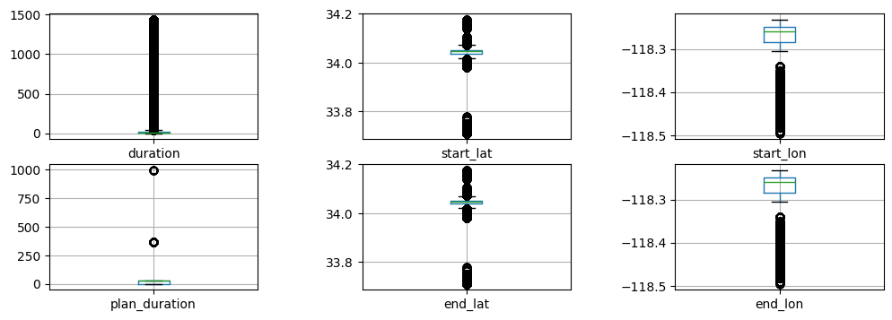

```python
# A function to show outliers for numeric columns
def boxplot_numeric_columns():
    fig, axes = plt.subplots(nrows=2, ncols=3,figsize=(12, 4))
    plt.subplots_adjust(wspace=.5)
    trips.boxplot(column='duration', ax=axes[0,0])
    trips.boxplot(column='plan_duration', ax=axes[1,0])
    trips.boxplot(column='start_lat', ax=axes[0,1])
    trips.boxplot(column='start_lon', ax=axes[0,2])
    trips.boxplot(column='end_lat', ax=axes[1,1])
    trips.boxplot(column='end_lon', ax=axes[1,2])

# box plot
boxplot_numeric_columns()
```

The figure for durations above shown that most of the trip times were within 60 minutes. This will be discussed following. Additionally, the figure for plan durations shown that outliers were concentrated in two values. Besides, the figures for latitudes and longitudes shown stations were clustered in multiple areas.

### Handling Outliers for Durations

```python
# Calculate Inter Quartile Range
q1 = trips.duration.quantile(0.25)
q3 = trips.duration.quantile(0.75)
m95 = trips.duration.quantile(0.95)
m98 = trips.duration.quantile(0.98)
# calculate upper limit
upper_limit = q3 + 1.5 * (q3 - q1)
print(f'Q1: {q1}, Q3: {13}, upper limit: {upper_limit}')
print(f'Over 95% trips were <= {m95} minutes and over 98% trips were <= {m98} minutes.')
```

```
Q1: 6.0, Q3: 13, upper limit: 46.0
Over 95% trips were <= 76.0 minutes and over 98% trips were <= 184.0 minutes.
```

The result shown that the suggested upper limit is 46 minutes and riding time recommonded by service companies was less than 60 minutes [2]. Thus durations within [60, 180] are replaced by 60 and rows with durations over 180 are removed.

```python
# removing outliers
pre_length = len(trips)
trips = trips[trips.duration < 180]
trips.duration = np.where(trips.duration > 60, 60, trips.duration)
print(f'{pre_length - len(trips)} rows were removed.')
```

```
1887 rows were removed.
```

### Handling Outliers for Plan Durations

```python
# A overview of plan duration
trips.plan_duration.value_counts()
```

```
plan_duration
30     56862
1      23451
365     9880
999       44
Name: count, dtype: int64
```

The result shows that most of the plans were 1 or 30 days and the number were an exponential difference. Here was considered a logarithm on base 10 value.

```python
trips.plan_duration = np.log10(trips.plan_duration).round(1)
trips.plan_duration.unique()
```

```
array([1.5, 0. , 2.6, 3. ])
```

### Handling Outliers for Latitudes and Longitudes

THere is a map view the stations by latitudes and longitudes, which may provide a meaningful perspective, instead of tables.

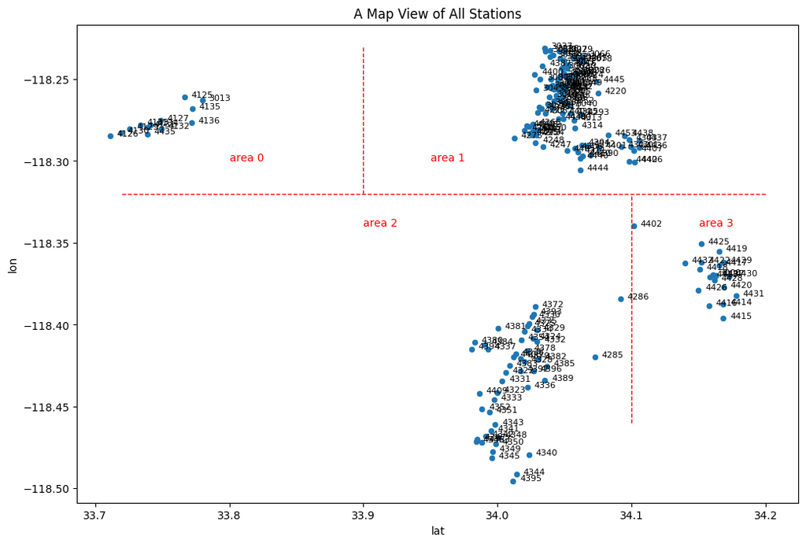

```python
# A map view of stations
def map_view_stations():
    locations = []
    for k, (lat, lon) in station_map.items():
        locations.append([k, lat, lon])
    location_df = pd.DataFrame(locations, columns=['station', 'lat', 'lon'])
    location_df[['lat', 'lon']].plot.scatter(x='lat', y='lon', figsize=(12, 8))
    for i in range(len(location_df)):
        row = location_df.iloc[i]
        plt.text(row.lat + 0.005, row.lon, str(int(row.station)), size=8)

map_view_stations()
plt.title('A Map View of All Stations')
plt.plot([33.9, 33.9], [-118.32, -118.23], ls='--', lw=1, c='red')
plt.plot([33.72, 34.2], [-118.32, -118.32], ls='--', lw=1, c='red')
plt.plot([34.1, 34.1], [-118.46, -118.32], ls='--', lw=1, c='red')
plt.text(33.8, -118.30, 'area 0', size=10, c='red')
plt.text(33.95, -118.30, 'area 1', size=10, c='red')
plt.text(33.9, -118.34, 'area 2', size=10, c='red')
plt.text(34.15, -118.34, 'area 3', size=10, c='red');
```

As the map shown, there were mainly 3 or 4 areas and different areas had a clear distance. It is meaningful to shorten the distance between areas such as moving stations in other areas closer to area 1.

```python
# find latitudes and langitudes for key boundary stations
print('Locations for key boundary stations:\nstation  latitude  longitude')
for _station in [3013, 4275, 4444, 4286, 4402]:
    print(f'{_station}: {station_map[_station]}')
```

```
Locations for key boundary stations:
station  latitude  longitude
3013: [33.779819, -118.263023]
4275: [34.01252, -118.285896]
4444: [34.061619, -118.305573]
4286: [  34.091889 -118.384367]
4402: [34.101509, -118.33979]
```

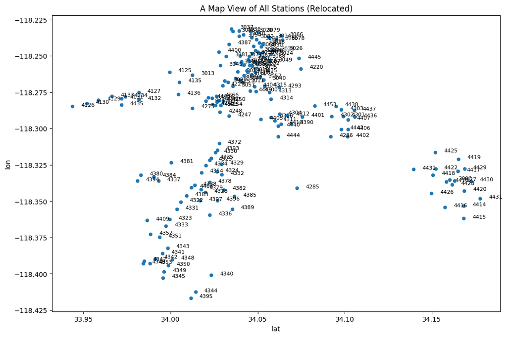

```python
# Moving stations in area 0 closer to area 1 by latitude direction
trips.loc[:,'start_lat'] = np.where(trips.start_lat <= 33.779819, trips.start_lat + (34.01252-33.779819), trips.start_lat)
trips.loc[:,'end_lat'] = np.where(trips.end_lat < 33.779819, trips.end_lat + (34.01252-33.779819), trips.end_lat)
# Moving stations in area 2 closer to area 1 by longitude direction
trips.loc[:,'start_lon'] = np.where((trips.start_lat <= 34.091889)&(trips.start_lon <= -118.384367),
                                    trips.start_lon + (-118.305573+118.384367), trips.start_lon)
trips.loc[:,'end_lon'] = np.where((trips.end_lat <= 34.091889)&(trips.end_lon <= -118.384367),
                                  trips.end_lon + (-118.305573+118.384367), trips.end_lon)
# Moving stations in area 3 closer to area 1 by longitude direction
trips.loc[:,'start_lon'] = np.where((trips.start_lat >=34.101509)&(trips.start_lon <= -118.33979),
                                    trips.start_lon + (-118.305573+118.33979), trips.start_lon)
trips.loc[:,'end_lon'] = np.where((trips.end_lat >= 34.101509)&(trips.end_lon <= -118.33979),
                                  trips.end_lon + (-118.305573+118.33979), trips.end_lon)
# Updating station map
station_map = calculate_station_map()
# Map view the new stations
map_view_stations()
plt.title('A Map View of All Stations (Relocated)');
```

The map above is much better and acceptable now.

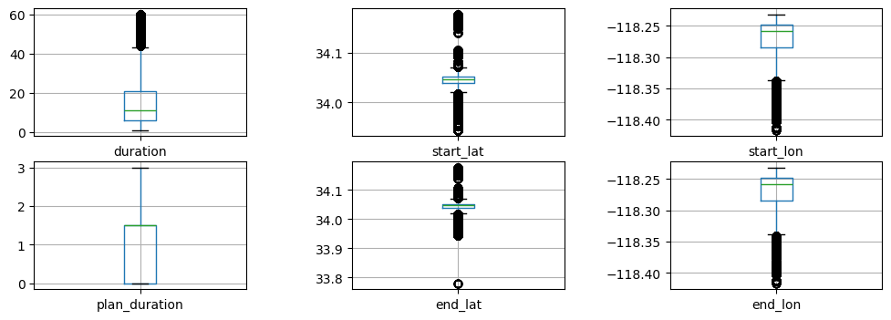

```python
# box plot
boxplot_numeric_columns()
```

## Transformation of Categorical Data

### Transformation of Datetime

Generally speaking, bike users choose relatively fixed dates and times to travel. For this reason, start_time should be replaced by day of year, day of week and hour, so that the rules are easier to be found.

```python
# extract dates and hours for further analysis and visualization
trips['day_of_year'] = trips.start_time.dt.day_of_year
trips['day_of_week'] = trips.start_time.dt.day_of_week
trips['hour'] = trips.start_time.dt.hour
trips['date'] = trips.start_time.dt.date
```

### Extracting Data for Training Dataset

The encoded dataset will completely change the data, including values and data types. Thus it is helpful to store data into a new variable.

```python
# define a dataframe for the output dataset
trips_final = trips[['duration', 'start_lat', 'start_lon', 'end_lat', 'end_lon',
                     'plan_duration', 'passholder_type', 'bike_type',
                     'day_of_year', 'day_of_week', 'hour']]
```

### Transformation of Categorical Data - Encoding

There are two categorical columns, passholder_type and bike_type, to be encoded. As they seem more like ordianal, ordinal encoding is applied for these columns.

```python
# define mappings
passholder_type_mapping = {'Walk-up': 0, 'One Day Pass': 1, 'Monthly Pass': 2, 'Flex Pass': 3,'Annual Pass': 4, 'Testing': 5}
bike_type_mapping = {'standard': 0, 'electric': 1, 'smart': 2}

# convert columns to categorical datatype
trips_final = trips_final.astype({'passholder_type': 'category','bike_type': 'category'})

# convert columns to number
trips_final = trips_final.assign(passholder_type=lambda _r: _r.passholder_type.cat.rename_categories(passholder_type_mapping),
                                 bike_type=lambda _r: _r.bike_type.cat.rename_categories(bike_type_mapping))
trips_final.head(1)
```

|  | duration | start_lat | start_lon | end_lat | end_lon | plan_duration | passholder_type | bike_type | day_of_year | day_of_week | hour |
| --- | --- | --- | --- | --- | --- | --- | --- | --- | --- | --- | --- |
| 0 | 5 | 34.06699 | -118.290878 | 34.063351 | -118.296799 | 1.5 | 2 | 0 | 182 | 0 | 0 |

## Transformation of Numerical Data

A research by Sujon [3] shows that through training, it is important to use data scaling techniques such as normalization and standardization to improve model performance. Moreover, standardization normally perform better for linear models such as SVM and LR.

```python
# define standard scaler for standardization
scaler = StandardScaler()
# copy of column names
trips_final_columns = trips_final.columns
# transform data
trips_final = pd.DataFrame(scaler.fit_transform(trips_final).round(3), columns=trips_final_columns)
trips_final.to_csv('data/metro_final.csv', index=False)
trips_final.head(1)
```

|  | duration | start_lat | start_lon | end_lat | end_lon | plan_duration | passholder_type | bike_type | day_of_year | day_of_week | hour |
| --- | --- | --- | --- | --- | --- | --- | --- | --- | --- | --- | --- |
| 0 | -0.77 | 0.816 | -0.285 | 0.609 | -0.405 | 0.334 | 0.382 | -1.242 | -1.793 | -1.45 | -2.897 |

# Insights and interpretations from data visualizations

## Trends of trips

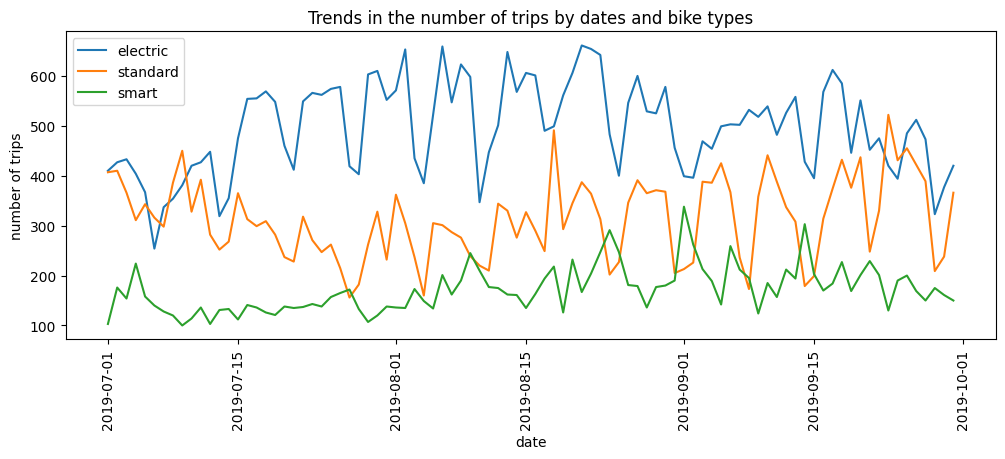

```python
# count the trips by date and bike types and plot them into a graph
trips[(trips.bike_type=='electric')].groupby(['date'])['date'].count().plot(figsize=(12, 4), label='electric')
trips[(trips.bike_type=='standard')].groupby(['date'])['date'].count().plot(label='standard')
trips[(trips.bike_type=='smart')].groupby(['date'])['date'].count().plot(label='smart')
plt.title('Trends in the number of trips by dates and bike types')
plt.ylabel('number of trips')
plt.legend(loc='upper left')
plt.xticks(rotation=90);
```

The above graph shows that electric and standard pedal-powered bikes have obvious periodic changes by weeks. Additionally, after 1st of September, there was an increase on standard bikes. Conversely, there was a slightly decrease on electric bikes.

## Trends of Trips in a Day

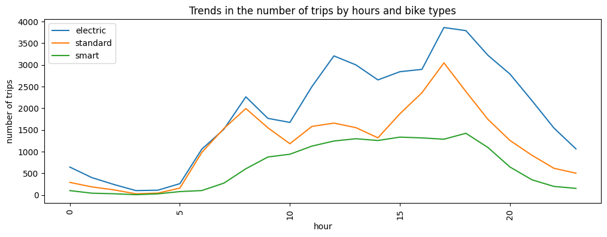

```python
# count the trips by hour and bike types and plot them into a graph
trips[(trips.bike_type=='electric')].groupby(['hour'])['hour'].count().plot(figsize=(12, 4), label='electric')
trips[(trips.bike_type=='standard')].groupby(['hour'])['hour'].count().plot(label='standard')
trips[(trips.bike_type=='smart')].groupby(['hour'])['hour'].count().plot(label='smart')
plt.title('Trends in the number of trips by hours and bike types')
plt.ylabel('number of trips')
plt.legend(loc='upper left')
plt.xticks(rotation=90);
```

As the trends shown above, there were about 3 peak times (8:30, 12:00, 17:00) for electric and standard bikes respectivily. For smart bikes, the number of trips increased rapidly in the morning, then maitained a slow growth rate, and finally reached a peak at 18:00.

## The Distributions of Numerical Columns

There is plots for distributions of duration, start latitude, start longitude, end latitude, end longitude columns.

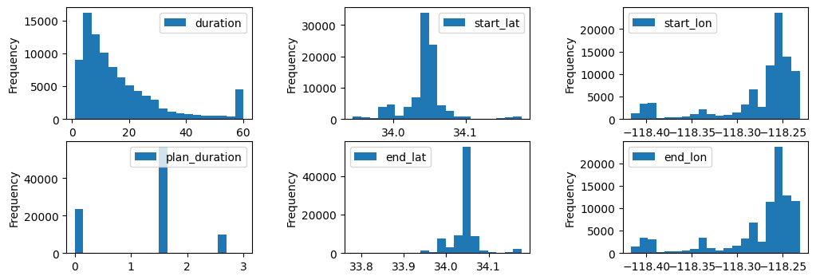

```python
# Subplots for numerical columns
fig, axes = plt.subplots(nrows=2, ncols=3,figsize=(12, 4))
plt.subplots_adjust(wspace=.5)
trips.plot.hist(column='duration', ax=axes[0,0], bins=20)
trips.plot.hist(column='plan_duration', ax=axes[1,0], bins=20)
trips.plot.hist(column='start_lat', ax=axes[0,1], bins=20)
trips.plot.hist(column='start_lon', ax=axes[0,2], bins=20)
trips.plot.hist(column='end_lat', ax=axes[1,1], bins=20)
trips.plot.hist(column='end_lon', ax=axes[1,2], bins=20);
```

### Correlation

Here was a pairwise correlation analysis for the selected transformated data.

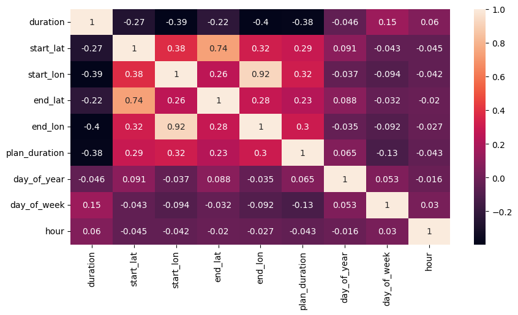

```python
plt.figure(figsize=(10, 5))
sns.heatmap(trips[['duration', 'start_lat', 'start_lon', 'end_lat', 'end_lon', 'plan_duration', 'day_of_year', 'day_of_week',
                  'hour']].corr(numeric_only=True), annot=True);
```

## The Difference of the Trip Numbers between Entering and Leaving Trips of a Station

Due to the particularity of the business, users are not responsible for balancing the supply of bikes. Some anomalies found in the data are helpful to improve the quality of service.

```python
# numbers of trips of start stations
start_station_nums = trips.start_station.value_counts()
# numbers of trips of end stations
end_station_nums = trips.end_station.value_counts()
difference = []
for station, in_num in end_station_nums.items():
    out_num = start_station_nums.get(station, 0)
    difference.append([station, in_num - out_num])
difference.sort(key=lambda x: -x[1])
difference = pd.DataFrame(difference, columns=['station', 'num'])
difference = difference.set_index('station')
difference.iloc[[0,1,-2,-1]]
```

| station | num |
| --- | --- |
| 3000 | 772 |
| 4285 | 478 |
| 3030 | -478 |
| 3068 | -530 |

### A Map View of the Difference of the Trip Numbers between Entering and Leaving a Station

As the result shown above, there were more bikes drived-in than drived-out to some stations. It is significant to show the problem on a map.

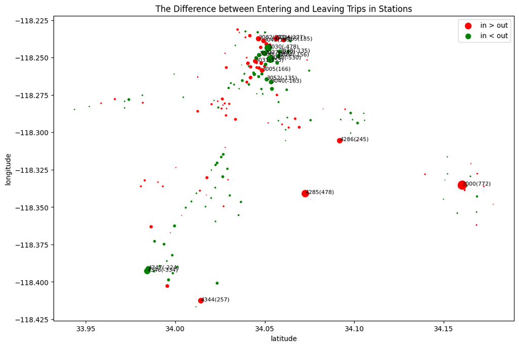

```python
# Wraping a list for station information
stations = [[station, *station_map[station], difference.loc[station].num, start_station_nums.loc[station]]
               for station in trips.start_station.unique()]
stations_df = pd.DataFrame(stations, columns=['station', 'lat', 'lon', 'sur', 'trip_num'])

locations_diff = stations_df[stations_df.sur >= 0]
ax = locations_diff[['lat', 'lon']].plot.scatter(x='lat', y='lon', c='r', s=locations_diff.sur/5, figsize=(12,8), label='in > out')
stations_less = stations_df[stations_df.sur < 0]
stations_less[['lat', 'lon']].plot.scatter(ax=ax, x='lat', y='lon', c='g', s=abs(stations_less.sur)/5, label='in < out')
# the list of top difference of trips
top_differences = difference[:10].index.to_list() + difference[-10:].index.to_list()
# mark station ids and differences on the graph
for i in range(len(stations_df)):
    _row = stations_df.iloc[i]
    if _row.station in top_differences:
        plt.text(_row.lat, _row.lon, f'{int(_row.station)}({difference.loc[_row.station].num})', size=8)
plt.title(f'The Difference between Entering and Leaving Trips in Stations')
plt.xlabel('latitude')
plt.ylabel('longitude')
plt.legend(loc='upper right');
```

The above graph shows that the short-term effect of bikes occur at several nearby stations, resulting in more uneven distribution.

## A Map View of the Top Popular Trips and Stations

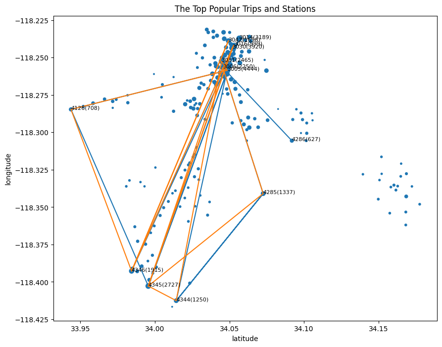

```python
# filter stations in area 1 and label trips by stations(ignoring the direction)
trips['start_end'] = trips.apply(lambda _row: f'{min(_row.start_station,_row.end_station)}-{max(_row.start_station,_row.end_station)}', axis=1)
trips_1_count = trips.start_end.value_counts()[:15] # choose the top popular routes
stations_df.plot.scatter(x='lat', y='lon', s=np.sqrt(stations_df.trip_num), figsize=(10, 8)) # plot all stations

# wrap the positions of stations of routes
x1, y1, x2, y2 = [], [], [], []
station_of_popular_trips = set()
for _idx in trips_1_count.index:
    _start, _end = _idx.split('-')
    _start, _end = int(_start), int(_end)
    _val = trips_1_count[_idx]
    _idx,_start,_end,_val
    x1.append(station_map[_start][0])
    y1.append(station_map[_start][1])
    x2.append(station_map[_end][0])
    y2.append(station_map[_end][1])
    station_of_popular_trips.add(_start)
    station_of_popular_trips.add(_end)
# plot routes
plt.plot(x1, y1, x2, y2)
# mark stations of popular trips on the graph
for i in range(len(stations_df)):
    _row = stations_df.iloc[i]
    if _row.station in station_of_popular_trips:
        plt.text(_row.lat, _row.lon, f'{int(_row.station)}({int(_row.trip_num)})', size=8)
plt.xlabel('latitude')
plt.ylabel('longitude')
plt.title('The Top Popular Trips and Stations');
```

The graph above shows that popular stations include stations in central areas and some scattered stations.

# Summary

Overall, the dataset was well collected by sharing bike servicesy. Though there were some missing values of locations, it has little impact. The data exploratory analysis above shows that:

- The stations were concentrated in several areas and were relocated closer during data processing.
- The trips have periodic changes by weeks and by days.
- The short-term effect of bikes occur at nearby stations, resulting in more uneven distribution.
- There were some popular stations contributed lots of short or long trips.

Finally, selected columns were standarized and the dataset was saved to a file ('data/metro_final.csv') for further mordeling.

# References

- 1. Clément Robert. (2024, April 10). User Guide — pandas 1.0.4 documentation. Pandas.pydata.org. https://pandas.pydata.org/docs/user_guide/index.html#
- 2. user-guideWikipedia Contributors. (2024, November 7). Bicycle-sharing system. Wikipedia; Wikimedia Foundation. https://en.wikipedia.org/wiki/Bicycle-sharing_system#Categorization
- 3. Khaled Mahmud Sujon, Hassan, R. B., Zeba Tusnia Towshi, Othman, M. A., Samad, M. A., & Choi, K. (2024). When to Use Standardization and Normalization: Empirical Evidence from Machine Learning Models and XAI. IEEE Access, 1–1. https://doi.org/10.1109/access.2024.3462434